# RNA-Protein divergence conditioned on RNA-Ribo divergence

### Plots

For genes buffered at the Ribo level compared to the RNA level, plot out per gene effect sizes of RNA and protein for genes that are buffered at protein, non-buffered at protein and that do not have significant interaction between RNA and protein.

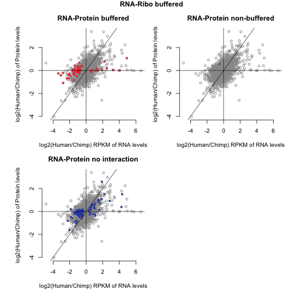

```r
## Plot out effect sizes calculated from
## un-normalized data
plot_matrix <- cbind(xy.rnapro$rna, xy.rnapro$pro)

## Make a panel for 4 plots
par( mfrow = c(2,2), mar = c(4, 4, 3, 1), oma = c(1, 2, 1, 1),
     cex.main = 1.2, cex.axis = 1)
title_list <- list("RNA-Protein buffered",
                   "RNA-Protein non-buffered",
                   "RNA-Protein no interaction")
index_list <-
  list( ii_buff_pro_buff =
        (ii_rnaGTpro & ii_sig_rnapro) & (ii_rnaGTribo & ii_sig_rnaribo),
        ii_buff_pro_nobuff =
        (ii_proGTrna & ii_sig_rnapro) & (ii_rnaGTribo & ii_sig_rnaribo),
        ii_buff_no_interact = (!ii_sig_rnapro) & ii_rnaGTribo & ii_sig_rnaribo )
col_list <- crayon[c("Orange Red", "Pine Green", "Violet Blue")]
for (i in 1:length(index_list)) {
    plot(plot_matrix, col = "gray60", cex = .8, ann = FALSE, axes = FALSE)
    points(plot_matrix[ which( index_list[[i]] ), ],
           col = col_list[[i]], pch = 16, cex = .7)
    abline(0, 1, v = 0, h = 0, col = crayon["Black"], lwd = .8)
    axis(1); axis(2)
    title(main = title_list[[i]],
          xlab = "log2(Human/Chimp) RPKM of RNA levels",
          ylab = "log2(Human/Chimp) of Protein levels")
}
title(main = "RNA-Ribo buffered", outer = TRUE)
```

For genes that are not buffered at the Ribo level compared to the RNA level, plot out per gene effect sizes of RNA and protein for genes that are buffered at protein, non-buffered at protein and that do not have significant interaction between RNA and protein.

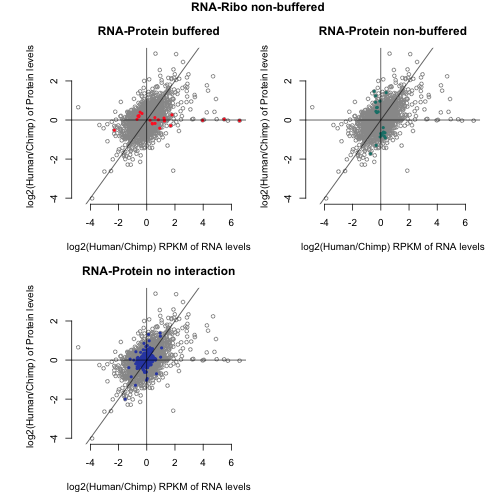

```r
## Plot out effect sizes calculated from
## un-normalized data
plot_matrix <- cbind(xy.rnapro$rna, xy.rnapro$pro)

## Make a panel for 4 plots
par( mfrow = c(2,2), mar = c(4, 4, 3, 1), oma = c(1, 2, 1, 1),
     cex.main = 1.2, cex.axis = 1)
title_list <- list("RNA-Protein buffered",
                   "RNA-Protein non-buffered",
                   "RNA-Protein no interaction")
index_list <-
  list( ii_nobuff_pro_buff =
      (ii_rnaGTpro & ii_sig_rnapro) & (ii_riboGTrna & ii_sig_rnaribo),
      ii_nobuff_pro_nobuff =
      (ii_proGTrna & ii_sig_rnapro) & (ii_riboGTrna & ii_sig_rnaribo),
      ii_nobuff_no_interact = (!ii_sig_rnapro) & ii_riboGTrna & ii_sig_rnaribo )
col_list <- crayon[c("Orange Red", "Pine Green", "Violet Blue")]
for (i in 1:length(index_list)) {
    plot(plot_matrix, col = "gray60", cex = .8, ann = FALSE, axes = FALSE)
    points(plot_matrix[ which( index_list[[i]] ), ],
           col = col_list[[i]], pch = 16, cex = .7)
    abline(0, 1, v = 0, h = 0, col = crayon["Black"], lwd = .8)
    axis(1); axis(2)
    title(main = title_list[[i]],
          xlab = "log2(Human/Chimp) RPKM of RNA levels",
          ylab = "log2(Human/Chimp) of Protein levels")
}
title(main = "RNA-Ribo non-buffered", outer = TRUE)
```

We look further into the genes that were buffered at the Ribo level and had no significant inter-species difference between RNA and Protein.

**Question**: We see in the scatter plot, some genes have a much larger effect size at the RNA level compared to the protein level. Yet, these genes did not show significant difference between inter-species differences at the RNA level and and the protein level.

**A possible explanation**: Maybe these genes have a larger variance at the RNA level compared to the protein level. Because statistial significance is a function of effect size and variance, perhaps the size of the variances of these genes canceled out the large effect size of these genes.

```r
## Compute per gene variance estimate for RNA data and for protein data
## We first compute variances among species and then take the average of
## the two to be the per gene variance estimates

load( file.path(rdadir,"eSetRRP.rda") )
eSet.temp <- eSetRRP.log2[ ,eSetRRP.log2$species!="rhesus"]
require(matrixStats)
varmat <- lapply( seq_along( c("human","chimp") ), function(i) {
  ii <- eSet.temp$species == c("human","chimp")[i]
  eSet.tt <- eSet.temp[, ii]
  emat <- lapply( seq_along( c("ribo","rna","protein") ), function(j) {
    jj <- eSet.tt$seqData == c("ribo","rna","protein")[j]
    rowVars( exprs(eSet.tt[, jj] ), na.rm=TRUE )
  })
  emat <- do.call(cbind, emat)
  colnames(emat) <- c("ribo","rna","protein")
  return( data.frame(emat) )
})
names(varmat) <- c("human","chimp")

varmat <- data.frame(
    rna = (varmat$human$rna + varmat$chimp$rna)/2,
    pro = (varmat$human$pro + varmat$chimp$pro)/2)
```

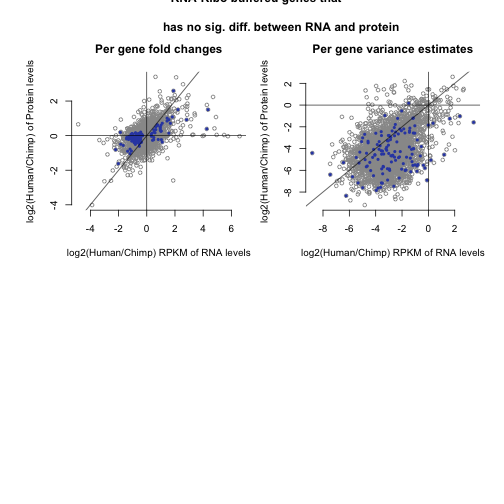

```r
par( mfrow = c(2,2), mar = c(4, 4, 4, 1), oma = c(1, 2, 2, 1),
     cex.main = 1.2, cex.axis = 1)
ii_buff_no_interact <- (!ii_sig_rnapro) & ii_rnaGTribo & ii_sig_rnaribo
plot(plot_matrix, col = "gray60", cex = .8, ann = FALSE, axes = FALSE)
points(plot_matrix[ which( ii_buff_no_interact ), ],
       col = crayon["Violet Blue"], pch = 16, cex = .7)
abline(0, 1, v = 0, h = 0, col = crayon["Black"], lwd = .8)
axis(1); axis(2)
title(main = "Per gene fold changes",
      xlab = "log2(Human/Chimp) RPKM of RNA levels",
      ylab = "log2(Human/Chimp) of Protein levels")

plot(log2(varmat), col = "gray60", cex = .8, ann = FALSE, axes = FALSE)
points(log2(varmat[ which( ii_buff_no_interact ), ]),
       col = crayon["Violet Blue"], pch = 16, cex = .7)
abline(0, 1, v = 0, h = 0, col = crayon["Black"], lwd = .8)
axis(1); axis(2)
title(main = "Per gene variance estimates",
      xlab = "log2(Human/Chimp) RPKM of RNA levels",
      ylab = "log2(Human/Chimp) of Protein levels")

title(main = "RNA-Ribo buffered genes that \n
              has no sig. diff. between RNA and protein", outer = TRUE)
```

## Size approach

```r
buffering_matrix_size <-
    matrix(0, 3, 3,
     dimnames = list(rnaribo = c("Ribo buffered",
                                 "Ribo non-buffered",
                                 "Column sum"),
                   rnapro = c("Protein buffered",
                              "Protein non-buffered",
                              "Row sum") ) )

## Among the genes buffered at translation,
## count the number of genes buffered at protein,
## non-buffered at protein and the total number
buffering_matrix_size[1,1] <-
    sum( (ii_rnaGTpro)[ii_rnaGTribo & ii_sig_rnaribo])
buffering_matrix_size[1,2] <-
    sum( (ii_proGTrna)[ii_rnaGTribo & ii_sig_rnaribo])
buffering_matrix_size[1,3] <-
    sum(ii_rnaGTribo & ii_sig_rnaribo)


## Among the genes non-buffered at translation,
## count the number of genes buffered at protein,
## non-buffered at protein and the total number
buffering_matrix_size[2,1] <-
    sum( (ii_rnaGTpro )[ii_riboGTrna & ii_sig_rnaribo])
buffering_matrix_size[2,2] <-
    sum( (ii_proGTrna )[ii_riboGTrna & ii_sig_rnaribo])
buffering_matrix_size[2,3] <-
  sum(ii_riboGTrna & ii_sig_rnaribo)


## Of all genes with sig. difference in translation efficiency,
## count the number of genes buffered at protein,
## non-buffered at protein, and no interaction between RNA and protein
buffering_matrix_size[3,1] <-
    sum( (ii_rnaGTpro)[
        (ii_rnaGTribo | ii_riboGTrna) & ii_sig_rnaribo] )
buffering_matrix_size[3,2] <-
    sum( (ii_proGTrna)[
        (ii_rnaGTribo | ii_riboGTrna) & ii_sig_rnaribo ] )

## No. of genes with sig. translation efficiency
buffering_matrix_size[3,3] <- sum(ii_sig_rnaribo)

kable(buffering_matrix_size)
```

|  | Protein buffered | Protein non-buffered | Row sum |
| --- | --- | --- | --- |
| Ribo buffered | 183 | 5 | 188 |
| Ribo non-buffered | 175 | 115 | 290 |
| Column sum | 358 | 120 | 478 |

### Sig. testing

Of the genes with sig. translation efficiency difference between species, we consider the set of genes that were buffered at the Ribo level and test the null hypothesis that among these genes are as likely to be buffered at the protein level as to be non-buffered (null proportion = .5)

```r
prop.test(buffering_matrix_size[1,1],
          buffering_matrix_size[1,1] + buffering_matrix_size[1,2],
          p = .5)
```

```r
##
##  1-sample proportions test with continuity correction
##
## data:  buffering_matrix_size[1, 1] out of buffering_matrix_size[1, 1] + buffering_matrix_size[1, 2], null probability 0.5
## X-squared = 166.64, df = 1, p-value < 2.2e-16
## alternative hypothesis: true p is not equal to 0.5
## 95 percent confidence interval:
##  0.9356761 0.9901679
## sample estimates:
##         p
## 0.9734043
```

```r
binom.test(buffering_matrix_size[1,1],
          buffering_matrix_size[1,1] + buffering_matrix_size[1,2],
          p = .5)
```

```r
##
##  Exact binomial test
##
## data:  buffering_matrix_size[1, 1] and buffering_matrix_size[1, 1] + buffering_matrix_size[1, 2]
## number of successes = 183, number of trials = 188, p-value <
## 2.2e-16
## alternative hypothesis: true probability of success is not equal to 0.5
## 95 percent confidence interval:
##  0.9390288 0.9913092
## sample estimates:
## probability of success
##              0.9734043
```

### Plots

For genes buffered at the Ribo level compared to the RNA level, plot out per gene effect sizes of RNA and protein for genes that are buffered at protein and non-buffered at protein.

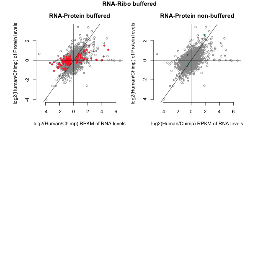

```r
## Plot out effect sizes calculated from
## un-normalized data
plot_matrix <- cbind(xy.rnapro$rna, xy.rnapro$pro)

## Make a panel for 4 plots
par( mfrow = c(2,2), mar = c(4, 4, 3, 1), oma = c(1, 2, 1, 1),
     cex.main = 1.2, cex.axis = 1)
title_list <- list("RNA-Protein buffered",
                   "RNA-Protein non-buffered",
                   "RNA-Protein no interaction")
index_list <-
  list( ii_buff_pro_buff =
        (ii_rnaGTpro) & (ii_rnaGTribo & ii_sig_rnaribo),
        ii_buff_pro_nobuff =
        (ii_proGTrna) & (ii_rnaGTribo & ii_sig_rnaribo) )
col_list <- crayon[c("Orange Red", "Pine Green")]
for (i in 1:length(index_list)) {
    plot(plot_matrix, col = "gray60", cex = .8, ann = FALSE, axes = FALSE)
    points(plot_matrix[ which( index_list[[i]] ), ],
           col = col_list[[i]], pch = 16, cex = .7)
    abline(0, 1, v = 0, h = 0, col = crayon["Black"], lwd = .8)
    axis(1); axis(2)
    title(main = title_list[[i]],
          xlab = "log2(Human/Chimp) RPKM of RNA levels",
          ylab = "log2(Human/Chimp) of Protein levels")
}
title(main = "RNA-Ribo buffered", outer = TRUE)
```

For genes that are not buffered at the Ribo level compared to the RNA level, plot out per gene effect sizes of RNA and protein for genes that are buffered at protein, non-buffered at protein.

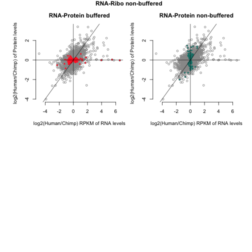

```r
## Plot out effect sizes calculated from
## un-normalized data
plot_matrix <- cbind(xy.rnapro$rna, xy.rnapro$pro)

## Make a panel for 4 plots
par( mfrow = c(2,2), mar = c(4, 4, 3, 1), oma = c(1, 2, 1, 1),
     cex.main = 1.2, cex.axis = 1)
title_list <- list("RNA-Protein buffered",
                   "RNA-Protein non-buffered",
                   "RNA-Protein no interaction")
index_list <-
  list( ii_nobuff_pro_buff =
      (ii_rnaGTpro) & (ii_riboGTrna & ii_sig_rnaribo),
      ii_nobuff_pro_nobuff =
      (ii_proGTrna) & (ii_riboGTrna & ii_sig_rnaribo) )
col_list <- crayon[c("Orange Red", "Pine Green")]
for (i in 1:length(index_list)) {
    plot(plot_matrix, col = "gray60", cex = .8, ann = FALSE, axes = FALSE)
    points(plot_matrix[ which( index_list[[i]] ), ],
           col = col_list[[i]], pch = 16, cex = .7)
    abline(0, 1, v = 0, h = 0, col = crayon["Black"], lwd = .8)
    axis(1); axis(2)
    title(main = title_list[[i]],
          xlab = "log2(Human/Chimp) RPKM of RNA levels",
          ylab = "log2(Human/Chimp) of Protein levels")
}
title(main = "RNA-Ribo non-buffered", outer = TRUE)
```

```r
## R version 3.2.1 (2015-06-18)
## Platform: x86_64-apple-darwin13.4.0 (64-bit)
## Running under: OS X 10.10.4 (Yosemite)
##
## locale:
## [1] en_US.UTF-8/en_US.UTF-8/en_US.UTF-8/C/en_US.UTF-8/en_US.UTF-8
##
## attached base packages:
## [1] parallel  stats     graphics  grDevices utils     datasets  methods
## [8] base
##
## other attached packages:
## [1] matrixStats_0.14.2  Humanzee_0.0.0.9000 devtools_1.9.0
## [4] broman_0.59-5       Biobase_2.28.0      BiocGenerics_0.14.0
## [7] knitr_1.11
##
## loaded via a namespace (and not attached):
##  [1] digest_0.6.8         assertthat_0.1       mime_0.3
##  [4] knitrBootstrap_1.0.0 formatR_1.2          magrittr_1.5
##  [7] evaluate_0.7.2       highr_0.5            stringi_0.5-5
## [10] rmarkdown_0.7        tools_3.2.1          stringr_1.0.0
## [13] markdown_0.7.7       yaml_2.1.13          memoise_0.2.1
## [16] htmltools_0.2.6
```

Styled with knitrBootstrap